# GLM - Example on Car Insurance Data

This study is inspired from the example extracted from the chapter 1 of the book Predictive Modeling Applications in Actuarial Science, from Frees & al. A very good book, very complete, that I deeply recommend for all the practitioners who would like to get knowledge in some modeling topics in Insurance.

In this markdown, we focus on the “bread and butter” of many Actuaries, namely the well known Claims frequency prediction. Another study concerning the prediction of the claims amount, namely “Severity”, will follow in another markdown.

```r
# Define columnn class for dataset
colCls <- c("integer",         # row id
            "character",       # analysis year
            "numeric",         # exposure
            "character",       # new business / renewal business
            "numeric",         # driver age (continuous)
            "character",       # driver age (categorical)
            "character",       # driver gender
            "character",       # marital status
            "numeric",         # years licensed (continuous)
            "character",       # years licensed (categorical)
            "character",       # ncd level
            "character",       # region
            "character",       # body code
            "numeric",         # vehicle age (continuous)
            "character",       # vehicle age (categorical)
            "numeric",         # vehicle value
            "character",       # seats
            rep("numeric", 6), # ccm, hp, weight, length, width, height (all continuous)
            "character",       # fuel type
            rep("numeric", 3)  # prior claims, claim count, claim incurred (all continuous)
)
```

```r
# Define the data path and filename
data.path <- "C:\\Users\\William.Tiritilli\\Documents\\Project P\\Frees\\Tome 2 - Chapter 1\\"
data.fn <- "sim-modeling-dataset2.csv"

# Read in the data with the appropriate column classes
dta <- read.csv(paste(data.path, data.fn, sep = "/"),
                colClasses = colCls)
str(dta)
```

```
## 'data.frame':    40760 obs. of  27 variables:
##  $ row.id        : int  1 2 3 4 5 6 7 8 9 10 ...
##  $ year          : chr  "2010" "2010" "2010" "2010" ...
##  $ exposure      : num  1 1 1 0.08 1 0.08 1 1 0.08 1 ...
##  $ nb.rb         : chr  "RB" "NB" "RB" "RB" ...
##  $ driver.age    : num  63 33 68 68 68 68 53 68 68 65 ...
##  $ drv.age       : chr  "63" "33" "68" "68" ...
##  $ driver.gender : chr  "Male" "Male" "Male" "Male" ...
##  $ marital.status: chr  "Married" "Married" "Married" "Married" ...
##  $ yrs.licensed  : num  5 1 2 2 2 2 5 2 2 2 ...
##  $ yrs.lic       : chr  "5" "1" "2" "2" ...
##  $ ncd.level     : chr  "6" "5" "4" "4" ...
##  $ region        : chr  "3" "38" "33" "33" ...
##  $ body.code     : chr  "A" "B" "C" "C" ...
##  $ vehicle.age   : num  3 3 2 2 1 1 3 1 1 5 ...
##  $ veh.age       : chr  "3" "3" "2" "2" ...
##  $ vehicle.value : num  21.4 17.1 17.3 17.3 25 ...
##  $ seats         : chr  "5" "3" "5" "5" ...
##  $ ccm           : num  1248 2476 1948 1948 1461 ...
##  $ hp            : num  70 94 90 90 85 85 70 85 85 65 ...
##  $ weight        : num  1285 1670 1760 1760 1130 ...
##  $ length        : num  4.32 4.79 4.91 4.91 4.04 ...
##  $ width         : num  1.68 1.74 1.81 1.81 1.67 ...
##  $ height        : num  1.8 1.97 1.75 1.75 1.82 ...
##  $ fuel.type     : chr  "Diesel" "Diesel" "Diesel" "Diesel" ...
##  $ prior.claims  : num  0 0 0 0 0 0 4 0 0 0 ...
##  $ clm.count     : num  0 0 0 0 0 0 0 0 0 0 ...
##  $ clm.incurred  : num  0 0 0 0 0 0 0 0 0 0 ...
```

```r
# Clean workspace
rm(data.path, data.fn, colCls)
```

I. Exploratory Analysis

We usually start our work by exploring individual variables to gain a better understanding on the info present in our dataset.

- clm.count: number of claims
- clm.incurred: the ultimate cost of those claims
1. EDA for Frequency

```r
# Create a summary table of frequency and severity
# by analysis period
yr.expo <- with(dta, tapply(exposure, year, sum)) #1. select the data, and 2. apply the sum of exposure by year
yr.clm.count <- with(dta, tapply(clm.count, year, sum)) # count the claims accross the year
yr.clm.incr <- with(dta, tapply(clm.incurred, year, sum))

yr.summary <- cbind(
  exposure = round(yr.expo,1),
  clm.count = yr.clm.count,
  clm.incurred = round(yr.clm.incr,0),
  frequency = round(yr.clm.count / yr.expo, 3),
  severity = round(yr.clm.incr / yr.clm.count, 1))


yr.summary <- rbind(yr.summary,
                    total = c(
                      round(sum(yr.expo),1),
                      sum(yr.clm.count),
                      round(sum(yr.clm.incr),0),
                      round(sum(yr.clm.count)/sum(yr.expo),3),
                      round(sum(yr.clm.incr)/sum(yr.clm.count),1)))
print(yr.summary)
```

```
##       exposure clm.count clm.incurred frequency severity
## 2010    3662.4       422       287869     0.115    682.2
## 2011    5221.3       551       314431     0.106    570.7
## 2012    6526.0      1278      1021152     0.196    799.0
## 2013    5385.1      1180      1087735     0.219    921.8
## total  20794.8      3431      2711187     0.165    790.2
```

We want to show the Evolution of the Empirical frequency and Exposure for all three years of the training data by driver age.

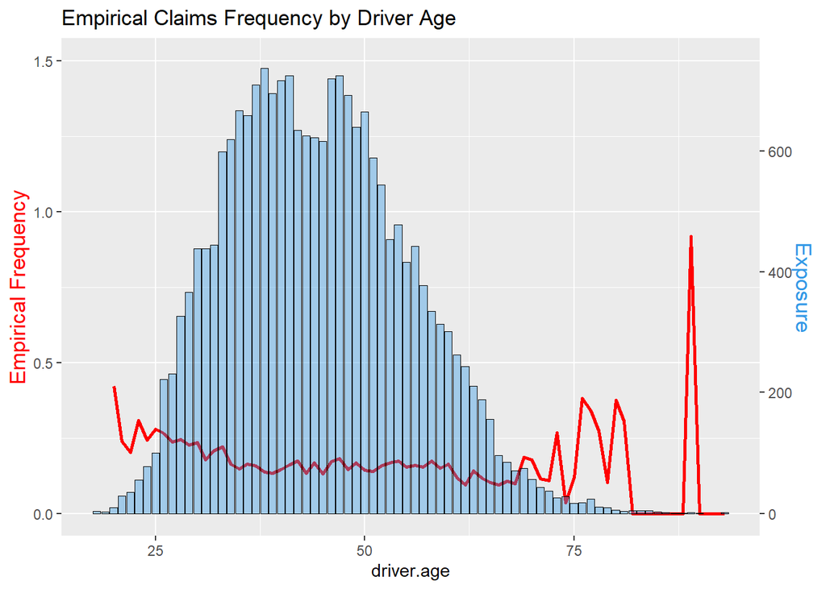

```r
library(ggplot2)
library(dplyr)
# Creation of the data frame
graph_data <- dta %>%  group_by(driver.age) %>%  summarise(Sum_Expo = sum(exposure),
                                               Number_of_Claims = sum(clm.count),
                                               Emp_freq = sum(clm.count)/sum(exposure))

# Bar plot overlapping with bar chart

# A few constants
freqColor <- "red"
expoColor <- rgb(0.2, 0.6, 0.9, 1)


# For the different scales,
# Set the following two values to values close to the limits of the data
# you can play around with these to adjust the positions of the graphs;
# the axes will still be correct)
ylim.prim <- c(0, 1)      # for claim frequency
ylim.sec <- c(0, 500)     # for Exposure --> need to go way above the max to let
                          # the data appearing in the chart
# For explanation:
# https://stackoverflow.com/questions/32505298/explain-ggplot2-warning-removed-k-rows-containing-missing-values

# The following makes the necessary calculations based on these limits,
# and makes the plot itself:
b <- diff(ylim.prim)/diff(ylim.sec)
a <- ylim.prim[1] - b*ylim.sec[1]

# Building the graph
graph_freq <- ggplot(graph_data, aes(x=driver.age, Emp_freq)) +

  geom_line( aes(y=Emp_freq), size=1, color=freqColor) +

    geom_bar( aes(y=a+Sum_Expo*b), stat="identity", size=.1, fill=expoColor, color="black", alpha=.4) +

  scale_y_continuous(

    # Features of the first axis
    name = "Empirical Frequency", limits = c(0, 1.5),

    # Add a second axis and specify its features
    sec.axis = sec_axis(~ (. - a)/b, name = "Exposure")
  ) +

  #theme_ipsum() +
  theme(
    axis.title.y = element_text(color = freqColor, size=13),
    axis.title.y.right = element_text(color = expoColor, size=13)
  ) +

  ggtitle("Empirical Claims Frequency by Driver Age")

# Print the whole graph
graph_freq
```

Now we want to see the pattern for each calendar year. A minor update of the previous code is required.

```r
# Creation of the data frame
graph_data2 <- dta %>%  group_by(driver.age, year) %>%  summarise(Sum_Expo = sum(exposure),
                                               Number_of_Claims = sum(clm.count),
                                               Emp_freq = sum(clm.count)/sum(exposure))
# Sort the dataframe by year
# https://dplyr.tidyverse.org/reference/arrange.html
graph_data2 <- arrange(graph_data2, year)
head(graph_data2)
```

```
## # A tibble: 6 x 5
## # Groups:   driver.age [6]
##   driver.age year  Sum_Expo Number_of_Claims Emp_freq
##        <dbl> <chr>    <dbl>            <dbl>    <dbl>
## 1         18 2010      1                   0   0
## 2         20 2010      0.75                0   0
## 3         21 2010      5.91                0   0
## 4         22 2010      4.08                0   0
## 5         23 2010     13.0                 0   0
## 6         24 2010     14.2                 1   0.0705
```

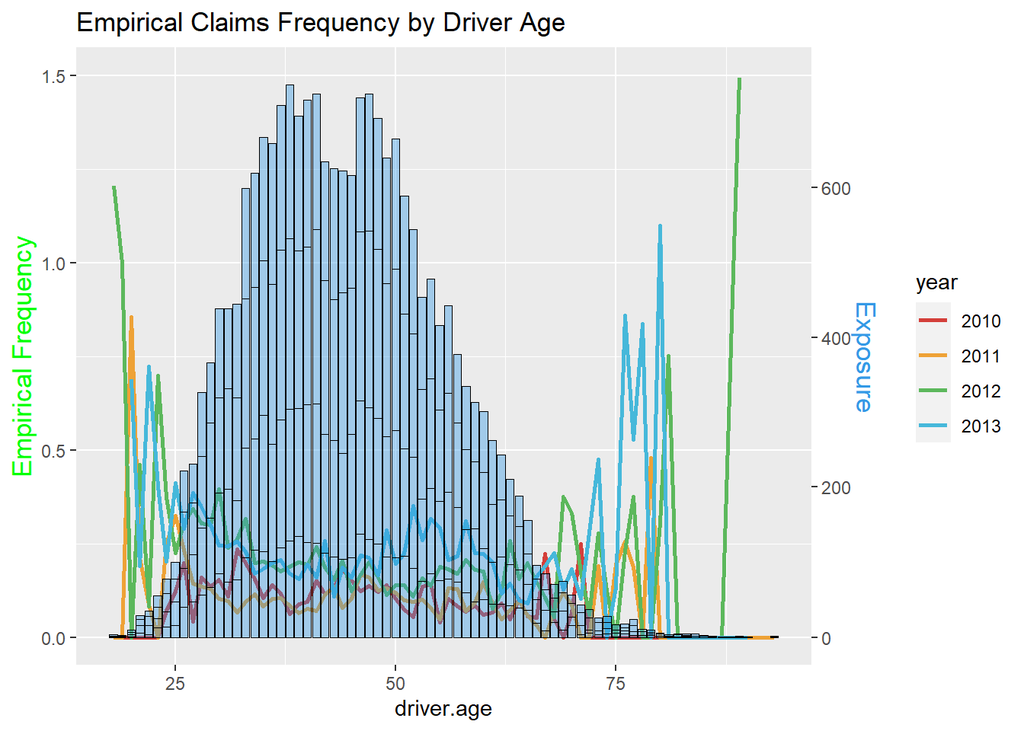

```r
# A few constants
freqColor <- c("#D43F3A", "#EEA236", "#5CB85C", "#46B8DA", "#9632B8")
expoColor <- rgb(0.2, 0.6, 0.9, 1)


# For the different scales,
# Set the following two values to values close to the limits of the data
# you can play around with these to adjust the positions of the graphs;
# the axes will still be correct)
ylim.prim <- c(0, 1)      # for claim frequency
ylim.sec <- c(0, 500)    # for Exposure --> need to go way above the max to let
                          # the data appearing in the chart
# For explanation:
# https://stackoverflow.com/questions/32505298/explain-ggplot2-warning-removed-k-rows-containing-missing-values

# The following makes the necessary calculations based on these limits,
# and makes the plot itself:
b <- diff(ylim.prim)/diff(ylim.sec)
a <- ylim.prim[1] - b*ylim.sec[1]

# Building the graph
graph_freq <- ggplot(graph_data2, aes(x=driver.age, year, y = Emp_freq, color=year)) +

  geom_line( aes(y=Emp_freq), size=1) +

  scale_color_manual(values = freqColor) +

    geom_bar( aes(y=a+Sum_Expo*b), stat="identity", size=.1, fill=expoColor, color="black", alpha=.4) +



  scale_y_continuous(

    # Features of the first axis
    name = "Empirical Frequency", limits = c(0, 1.5),


    # Add a second axis and specify its features
    sec.axis = sec_axis(~ (. - a)/b, name = "Exposure")
  ) +

  #theme_ipsum() +
  theme(
    axis.title.y = element_text(color = "green", size=13),
    axis.title.y.right = element_text(color = expoColor, size=13)
  ) +

  ggtitle("Empirical Claims Frequency by Driver Age")

# Print the whole graph
graph_freq
```

2013 and 2012 are very volatile for the younger age and the seniors. We observe that the individual calendar year frequency are more volatile than all the 4 years combined.

Let’s investigate some other variables, like the size of the engine (ccm). It is a continuous variable, so we can split it by ranges using the function ‘cut’. The package dplyr will help to summarize the information.

```r
# Size of Engine

# Creation of a categorical

# Check the quantile
ccm_quantile <- quantile(dta$ccm)
print(ccm_quantile)
```

```
##   0%  25%  50%  75% 100%
##  970 1398 1560 1896 3198
```

```r
dta$ccm_range <- cut(dta$ccm, breaks = c(ccm_quantile[1],
                                                         ccm_quantile[2],
                                                         ccm_quantile[3],
                                                         ccm_quantile[4],
                                         ccm_quantile[5]),
                       labels = c("970-1398","1399-1560",
                                  "1561-1896", "1897-3198"),include.lowest = TRUE)

# Use of the pipe to pivot the data
dta %>% group_by(ccm_range) %>% summarise(Sum_Expo = sum(exposure),
                                               Number_of_Claims = sum(clm.count),
                                               Emp_freq = sum(clm.count)/sum(exposure))
```

```
## # A tibble: 4 x 4
##   ccm_range Sum_Expo Number_of_Claims Emp_freq
##   <fct>        <dbl>            <dbl>    <dbl>
## 1 970-1398     6342.             1147    0.181
## 2 1399-1560    4872.              842    0.173
## 3 1561-1896    5665.              859    0.152
## 4 1897-3198    3916.              583    0.149
```

```r
# Example with another granularity
bk <- unique(quantile(dta$ccm, probs = seq(0, 1, by = 0.05)))
dta$ccm.d <- cut(dta$ccm, breaks = bk, include.lowest = TRUE)

dta %>% group_by(ccm.d) %>% summarise(Sum_Expo = sum(exposure),
                                               Number_of_Claims = sum(clm.count),
                                               Emp_freq = sum(clm.count)/sum(exposure))
```

```
## # A tibble: 12 x 4
##    ccm.d       Sum_Expo Number_of_Claims Emp_freq
##    <fct>          <dbl>            <dbl>    <dbl>
##  1 [970,1248]     4350.              759    0.174
##  2 (1248,1398]    1992.              388    0.195
##  3 (1398,1461]    3240.              540    0.167
##  4 (1461,1560]    1632.              302    0.185
##  5 (1560,1598]     590.               98    0.166
##  6 (1598,1753]    2302.              347    0.151
##  7 (1753,1868]     982.              156    0.159
##  8 (1868,1896]    1790.              258    0.144
##  9 (1896,1997]    1063.              162    0.152
## 10 (1997,2476]    1440.              196    0.136
## 11 (2476,2477]     557.               79    0.142
## 12 (2477,3198]     856.              146    0.171
```

The gender of the driver might help to predict the frequency of accidents.

```r
# Investigate the frequency of claims by the variables driver.gender and marital
library(tidyr)

# https://www.youtube.com/watch?v=AkaiM-Mm_Ag
dta %>% group_by(driver.gender, year) %>%
  summarise(emp_freq = round(sum(clm.count)/sum(exposure),3)*100) %>%
  spread(driver.gender, emp_freq)
```

```
## # A tibble: 4 x 3
##   year  Female  Male
##   <chr>  <dbl> <dbl>
## 1 2010    13.9  11.2
## 2 2011    11.5  10.4
## 3 2012    25.9  18.8
## 4 2013    24.8  21.5
```

```r
dta %>% group_by(marital.status, year) %>%
  summarise(emp_freq = sum(clm.count)/sum(exposure)) %>%
  spread(marital.status, emp_freq)
```

```
## # A tibble: 4 x 5
##   year  Divorced Married Single Widow
##   <chr>    <dbl>   <dbl>  <dbl> <dbl>
## 1 2010     0.117   0.115 0.0993 0.144
## 2 2011     0.114   0.106 0.0781 0.162
## 3 2012     0.188   0.190 0.254  0.475
## 4 2013     0.246   0.215 0.299  0.272
```

–> need to add the total.

Is the difference significant? We will randomly assign the label “married” to 22761 observations. Then, we compute the frequency of each group and take the difference.

```r
# Creation of a train set
smp_size <- floor(0.7 * nrow(dta))
# set the seed to make your partition reproductible
set.seed(1234)
train_ind <- sample(seq_len(nrow(dta)), size = smp_size)
train<-dta[train_ind, ]
test<-dta[-train_ind, ]
```

dim(train)

```r
set.seed(1029384756)

# We want to run the experiement 10000 times
N <- 10000

tmp <- subset(train, marital.status %in% c("Married", "Widow"), select =c("marital.status",
"exposure", "clm.count") )

# Create a dataframe tagging each label with TRUE or FALSE
f <- tmp$marital.status == "Married"

# Create an empty dataframe of size N
d <- numeric(N)

for(i in 1:N) {

# fct sample takes a sample of the specified size from the elements of x
g <- sample(f, length(f))

#
married.fq <- sum(tmp$clm.count[g]) / sum(tmp$exposure[g])
widow.fq <- sum(tmp$clm.count[!g]) / sum(tmp$exposure[!g])


# Compute the difference in frequencies between married and widow
# and store in a data frame of size N
d[i] <- married.fq - widow.fq

}
```

Results

```r
quantile(d, c(0.025, 0.05, 0.1, 0.25, 0.5,
0.75, 0.9, 0.95, 0.975))
```

```
##         2.5%           5%          10%          25%          50%          75%
## -0.064571057 -0.053498652 -0.040967588 -0.020689849  0.001010976  0.021646309
##          90%          95%        97.5%
##  0.039423875  0.049595680  0.057364579
```

We can verify this with a graph:

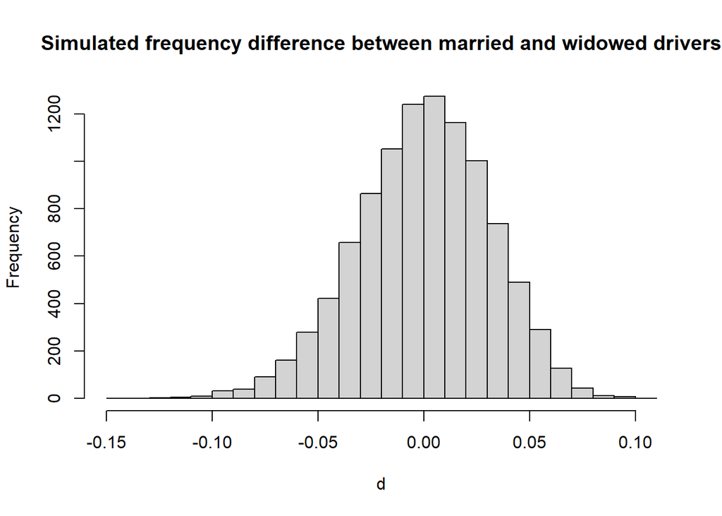

```r
hist(d, breaks = c(20), main = paste("Simulated frequency difference between married and widowed drivers"))
```

The actual difference between these groups is well outside the bulk of the distribution.

To conclude this EDA, let’s have a look at the variable age.

```r
dta$age.bins <- cut(dta$driver.age, c(0, 34, 64, 110))

dta %>% group_by(age.bins, driver.gender) %>%
  summarise(emp_freq = sum(clm.count)/sum(exposure)) %>%
  spread(age.bins, emp_freq)
```

```
## # A tibble: 2 x 4
##   driver.gender `(0,34]` `(34,64]` `(64,110]`
##   <chr>            <dbl>     <dbl>      <dbl>
## 1 Female           0.234     0.190      0.193
## 2 Male             0.216     0.149      0.132
```

Number of records by number of claims for the entire dataset

```r
table(dta$clm.count)
```

```
##
##     0     1     2     3     4     5
## 37591  2927   225    15     1     1
```

```r
dta %>% group_by(nb.rb) %>%
  summarise(clm_inc = sum(clm.incurred),
            clm.cnt = sum(clm.count),
            severity = clm_inc/clm.cnt) %>% as.data.frame()
```

```
##   nb.rb   clm_inc clm.cnt severity
## 1    NB 2160463.5    2633 820.5330
## 2    RB  550723.1     798 690.1291
```

# Frequency Modeling

To apply a GLM, we need to make two choices: link function and response distribution. For most insurance pricing, we would like to have a multiplicative rating plan so we will be using a logarithm link function. Concerning the distribution, we are modeling a claim count, so the natural candidate are Poisson or Negative Binomial.

Claims distribution

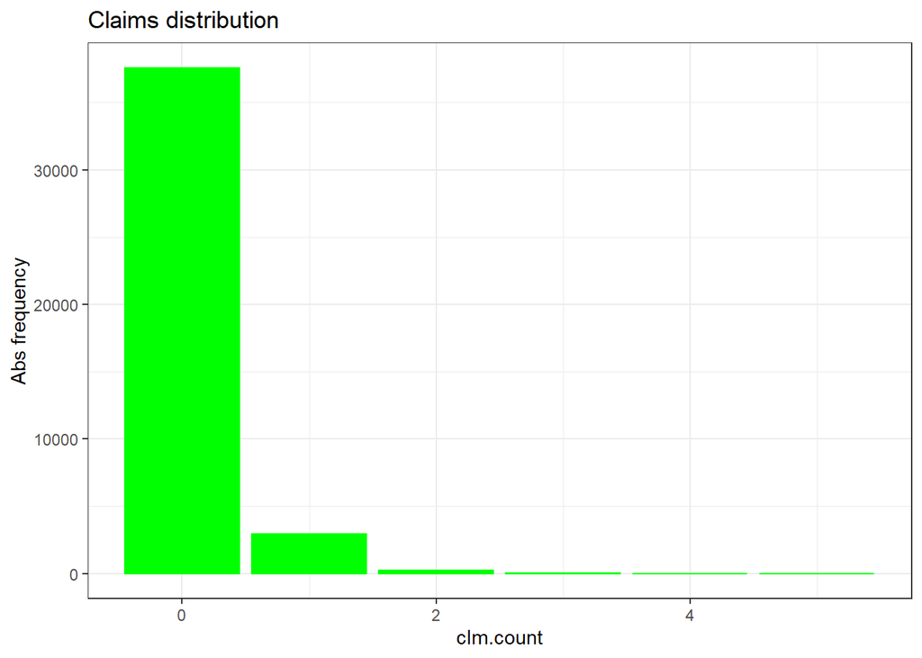

```r
KULBg = "green"
# same graph with the weight of the expo
g1 <- ggplot(dta, aes(clm.count)) + theme_bw()+
  geom_bar( col = KULBg, fill = KULBg) +
  labs(y="Abs frequency")+
  ggtitle("Claims distribution")

print(g1)
```

Let’s check if the assumption of Poisson having mean=variance are respected.

```r
f <- with(dta, clm.count / exposure) # frequency for each record
w <- with(dta, exposure) # weight for each record
mean.f <- sum(f * w) / sum(w) # mean frequency
second.f <- sum(f**2 * w) / sum(w) # second moment
var.f <- second.f - (mean.f)**2
print(var.f)
```

```
## [1] 0.3391072
```

```r
print(mean.f)
```

```
## [1] 0.1649933
```

We can see that mean and variance are not equal. In this case the variance is large than the mean, and we have an overdispersed dataset.

# Null Model

A model that estimates just the intercept term. It should replicate the mean of the distribution. Let’s verify this property.

```r
null_model<-glm(clm.count ~ 1, family = poisson(link = "log"), data=train, offset=log(exposure))

summary(null_model)
```

```
##
## Call:
## glm(formula = clm.count ~ 1, family = poisson(link = "log"),
##     data = train, offset = log(exposure))
##
## Deviance Residuals:
##     Min       1Q   Median       3Q      Max
## -0.5696  -0.4933  -0.3692  -0.2349   4.9604
##
## Coefficients:
##             Estimate Std. Error z value Pr(>|z|)
## (Intercept) -1.81865    0.02054  -88.54   <2e-16 ***
## ---
## Signif. codes:  0 '***' 0.001 '**' 0.01 '*' 0.05 '.' 0.1 ' ' 1
##
## (Dispersion parameter for poisson family taken to be 1)
##
##     Null deviance: 11520  on 28531  degrees of freedom
## Residual deviance: 11520  on 28531  degrees of freedom
## AIC: 16016
##
## Number of Fisher Scoring iterations: 6
```

```r
exp(null_model$coefficients[1])
```

```
## (Intercept)
##   0.1622449
```

By taking the inverse of the link function, the estimated frequency for the null model is 16.2% close to our mean calculated previously.

For the sake of clarity, let’s give some interpretation element. For this, we will focus on the categorical driver.gender

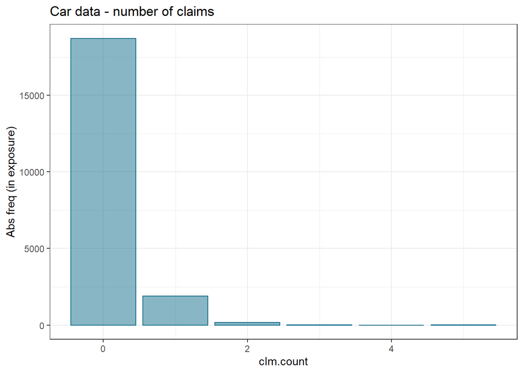

```r
library(ggplot2)

KULbg <- "#116E8A"

g_freq <- ggplot(dta, aes(clm.count)) + theme_bw() +
  geom_bar(aes(weight = exposure), col = KULbg,
           fill = KULbg, alpha = .5) +
  labs(y = "Abs freq (in exposure)") +
  ggtitle("Car data - number of claims")
g_freq
```

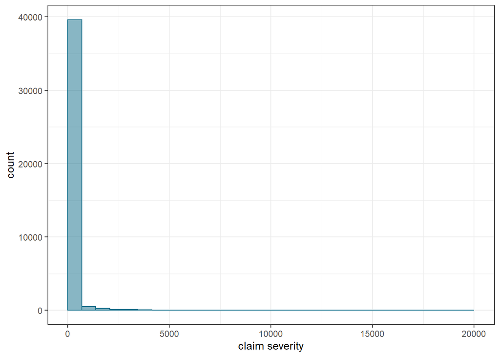

```r
g_sev <- ggplot(dta, aes(x = clm.incurred)) + theme_bw() +
  geom_histogram(bins = 30, boundary = 0, color = KULbg, fill = KULbg, alpha = .5) +
  labs(x = "claim severity") +
  xlim(c(0, 20000))
g_sev
```

```r
library(dplyr)
freq_by_gender <- dta %>%
  group_by(driver.gender) %>%
  summarize(emp_freq = sum(clm.count) / sum(exposure))
freq_by_gender
```

```
## # A tibble: 2 x 2
##   driver.gender emp_freq
##   <chr>            <dbl>
## 1 Female           0.200
## 2 Male             0.161
```

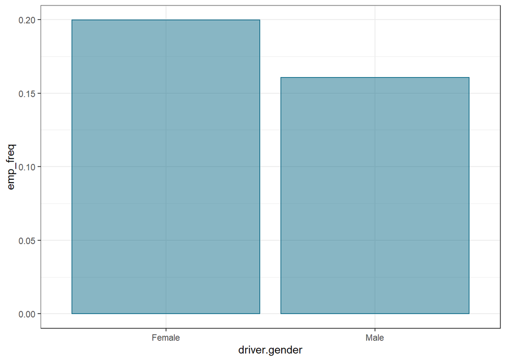

```r
ggplot(freq_by_gender, aes(x = driver.gender, y = emp_freq)) + theme_bw() +
  geom_bar(stat = "identity", col = KULbg, fill = KULbg, alpha = .5)
```

Split claim by driver gender

```r
with(dta, table(driver.gender, clm.count))
```

```
##              clm.count
## driver.gender     0     1     2     3     4     5
##        Female  4110   365    39     4     0     1
##        Male   33481  2562   186    11     1     0
```

```r
library(tidyverse)
freq_glm_1 <- glm(clm.count ~ driver.gender, offset = log(exposure),
                  family = poisson(link = "log"),
                  data = dta)
freq_glm_1 %>% broom::tidy()
```

```
## # A tibble: 2 x 5
##   term              estimate std.error statistic   p.value
##   <chr>                <dbl>     <dbl>     <dbl>     <dbl>
## 1 (Intercept)         -1.61     0.0466    -34.5  1.46e-261
## 2 driver.genderMale   -0.218    0.0501     -4.34 1.41e-  5
```

```r
summary(freq_glm_1)
```

```
##
## Call:
## glm(formula = clm.count ~ driver.gender, family = poisson(link = "log"),
##     data = dta, offset = log(exposure))
##
## Deviance Residuals:
##     Min       1Q   Median       3Q      Max
## -0.6320  -0.4909  -0.4008  -0.2606   4.7542
##
## Coefficients:
##                   Estimate Std. Error z value Pr(>|z|)
## (Intercept)       -1.61087    0.04663 -34.549  < 2e-16 ***
## driver.genderMale -0.21755    0.05010  -4.342 1.41e-05 ***
## ---
## Signif. codes:  0 '***' 0.001 '**' 0.01 '*' 0.05 '.' 0.1 ' ' 1
##
## (Dispersion parameter for poisson family taken to be 1)
##
##     Null deviance: 16616  on 40759  degrees of freedom
## Residual deviance: 16598  on 40758  degrees of freedom
## AIC: 23096
##
## Number of Fisher Scoring iterations: 6
```

Interpretation (cf. Charpentier, STT5100-11)

We want to model the annual frequency of claims according to the number of claims incurred during the exposure duration.

The modality Male Driver is significanlty different from Women Driver. The Coefficient -0.21 is also negative. We estimate that we should be around 20% less high in term of frequency for Male individual

there is 21% less chance to have an accident being a Male.

lambda represent my prediction for the annual frequency

lambda_1 = exp(-1.61)

lambda_1=exp(freq_glm_1$coefficients[1]) lambda_2=exp(freq_glm_1$coefficients[1]+freq_glm_1$coefficients[2])

(lambda_2-lambda_1)/lambda_1

Globally, we saw previously that the annual frequency was around 16%. If the driver is a woman, the frequency is a little higher at 20% If the driver is a man, the frequency is around 16% We are 20% lover for men than women in terms of annual frequency.

We can explore another predictor and see how we can group its levels together (binning) Let’s explore the variable “body.code”. It represents the vehicule characteristics, including the number of seats, its weight, lenght, width and height.

```r
dta %>% group_by(body.code) %>% summarise(count=n())
```

```
## # A tibble: 8 x 2
##   body.code count
##   <chr>     <int>
## 1 A         17472
## 2 B           712
## 3 C          2121
## 4 D         10090
## 5 E          8335
## 6 F           402
## 7 G          1374
## 8 H           254
```

```r
with(dta, table(body.code, clm.count))
```

```
##          clm.count
## body.code     0     1     2     3     4     5
##         A 16097  1273    93     7     1     1
##         B   685    26     1     0     0     0
##         C  1952   152    17     0     0     0
##         D  9300   732    53     5     0     0
##         E  7697   594    42     2     0     0
##         F   374    26     2     0     0     0
##         G  1261    99    13     1     0     0
##         H   225    25     4     0     0     0
```

A is the reference here.

```r
freq_glm_2 <- glm(clm.count ~ body.code, offset = log(exposure),
                  family = poisson(link = "log"),
                  data = dta)
summary(freq_glm_2)
```

```
##
## Call:
## glm(formula = clm.count ~ body.code, family = poisson(link = "log"),
##     data = dta, offset = log(exposure))
##
## Deviance Residuals:
##     Min       1Q   Median       3Q      Max
## -0.7102  -0.4911  -0.3750  -0.2428   4.9297
##
## Coefficients:
##             Estimate Std. Error z value Pr(>|z|)
## (Intercept) -1.78726    0.02592 -68.966  < 2e-16 ***
## body.codeB  -0.80222    0.19075  -4.206  2.6e-05 ***
## body.codeC   0.03463    0.07777   0.445   0.6561
## body.codeD  -0.01361    0.04294  -0.317   0.7512
## body.codeE  -0.04050    0.04619  -0.877   0.3806
## body.codeF  -0.16141    0.18440  -0.875   0.3814
## body.codeG   0.09679    0.09211   1.051   0.2934
## body.codeH   0.40964    0.17600   2.328   0.0199 *
## ---
## Signif. codes:  0 '***' 0.001 '**' 0.01 '*' 0.05 '.' 0.1 ' ' 1
##
## (Dispersion parameter for poisson family taken to be 1)
##
##     Null deviance: 16616  on 40759  degrees of freedom
## Residual deviance: 16584  on 40752  degrees of freedom
## AIC: 23094
##
## Number of Fisher Scoring iterations: 6
```

A is my reference lambda_A = exp(-1.78) lambda_D = lambda_A*exp(-0.013)

Graphically

```r
y = predict (freq_glm_2 , newdata = data.frame (
  body.code = LETTERS [1:8], exposure = 1) ,
    type ="response" , se.fit = TRUE ) # I take the std dev on all my class

# Function to represent the Annual Claim frequency by body
error.bar = function (x ,y , upper , lower , length =0.1 ,...) {
  arrows (x , y + upper , x , y - lower , angle =90 , code =3 ,
  length = length , ...) }
```

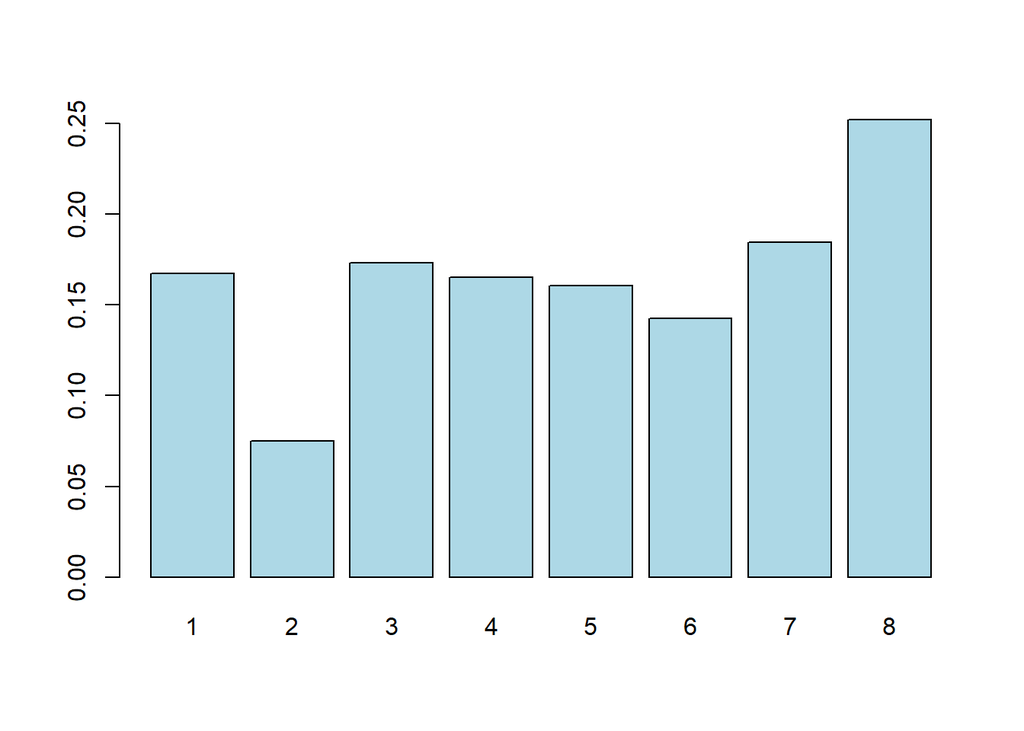

```r
barres = barplot ( y$fit , beside = TRUE , col ="light blue")
```

```r
#error.bar( barres , y$fit , y$se.fit )
```

Grouping possible between 3,4, 5 and 7.